# Использование технологии Yandex Query для анализа данных сетевой

## Задания

### Задание 1. Известно, что IP адреса внутренней сети начинаются с октетов, принадлежащих интервалу $$12-14$$ . Определите количество хостов внутренней сети, представленных в датасете.

- Считаем адреса src по маске “12.%” … “14.%” и т.д.

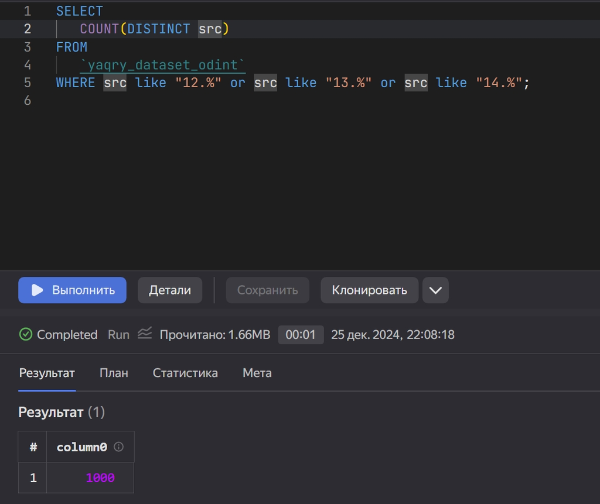

### Задание 2. Определите суммарный объем исходящего трафика.

- Ищем трафик, где src принадлежит внутренней сети, а dst нет.

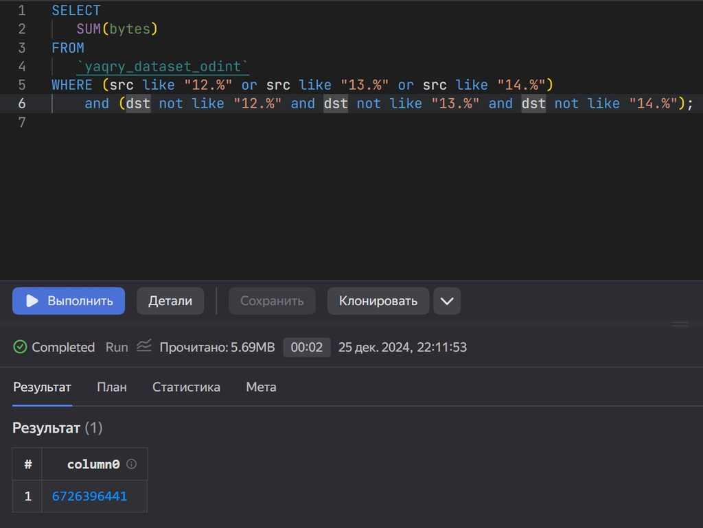

### Задание 3. Определите суммарный объем входящего трафика.

- Ищем трафик, где dst принадлежит внутренней сети, а src нет.

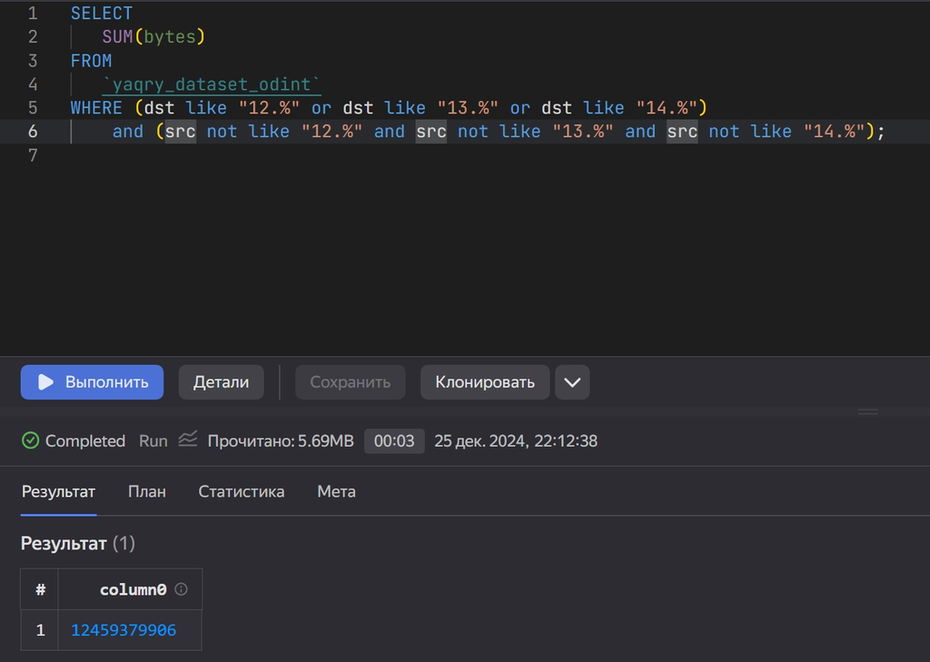

## Оценка результата

С использованием инструментов YandexQuery были проделаны задания по основам обработки данных.

## Вывод

Ознакомились с YandexQuery, повторили технологии анализа данных.